# Assignment3

Gianina Yumul

9/24/2020

# Assignment Brief

Creative Assignment 3: Identify a municipal open data portal and find two point layers (A and B) and two polygon layers (C and D). Calculate six of 22 possible metrics, and illustrate the results of each calculation with a map. Each of the four layers you selected should appear in at least one of those six maps.

Credit to Taelor for looking over my code on 9/25 and giving me the following feedback:

“Your issues in maps 2, 3 and 4 were stemming from the fact that you were using length instead of lengths in your mutate functions.” Taelor also gave me feedback about retrying a map with an overlapping polygons framework.

```r
knitr::opts_chunk$set(echo = TRUE)
```

```r
#Declare libraries while suppressing outputs.
library(sf, quietly = TRUE, warn.conflicts = FALSE)
library(tidyverse, quietly = TRUE, warn.conflicts = FALSE)
library(ggthemes, quietly = TRUE, warn.conflicts = FALSE)
library(ggspatial, quietly = TRUE, warn.conflicts = FALSE)
library(units, quietly = TRUE, warn.conflicts = FALSE)
library(nngeo, quietly = TRUE, warn.conflicts = FALSE)
library(wesanderson, quietly = TRUE, warn.conflicts = FALSE)
```

### Grabbing Data

I grabbed my data from NYC Open Data. I’ve included the descriptions accompanying each dataset as described by NYC Open Data.

NYC Parks Description: Planimetric basemap polygon layer containing open space features, such as courts, tracks, etc. including parks.

NYC Neighborhoods Description: Boundaries of Neighborhood Tabulation Areas as created by the NYC Department of City Planning using whole census tracts from the 2010 Census as building blocks. These aggregations of census tracts are subsets of New York City’s 55 Public Use Microdata Areas (PUMAs).

NYC Points of Interest Description: The Points Of Interest points are a compilation of what the different city agencies consider to be a Common Place or Place/Point of Interest.

NYC Subway Entrances Description: None.

```r
#From NYC Open Data.

#NYC Parks (polygons)
parks <- st_read("https://data.cityofnewyork.us/api/geospatial/g84h-jbjm?method=export&format=KML", quiet = TRUE)

#NYC Neighborhood (polygons)
nhoods <- st_read("https://data.cityofnewyork.us/api/geospatial/cpf4-rkhq?method=export&format=KML", quiet = TRUE)

#NYC Points of Interest (points)
poi <- st_read("https://data.cityofnewyork.us/api/geospatial/rxuy-2muj?method=export&format=KML", quiet = TRUE)

#NYC Subway Entrances (points)
subway <- st_read("https://data.cityofnewyork.us/api/geospatial/drex-xx56?method=export&format=KML", quiet = TRUE)
```

### Transforming Data

```r
#Transforming using the EPSG 2829 projection for New York.
NY_state_plane <- "+proj=tmerc +lat_0=40 +lon_0=-76.58333333333333 +k=0.9999375 +x_0=250000 +y_0=0 +ellps=GRS80 +units=m +no_defs "

parks <- parks %>%
  st_transform(NY_state_plane)

nhoods <- nhoods %>%
  st_transform(NY_state_plane)

poi <- poi %>%
  st_transform(NY_state_plane)

subway <- subway %>%
  st_transform(NY_state_plane)
```

### All Data Mapped

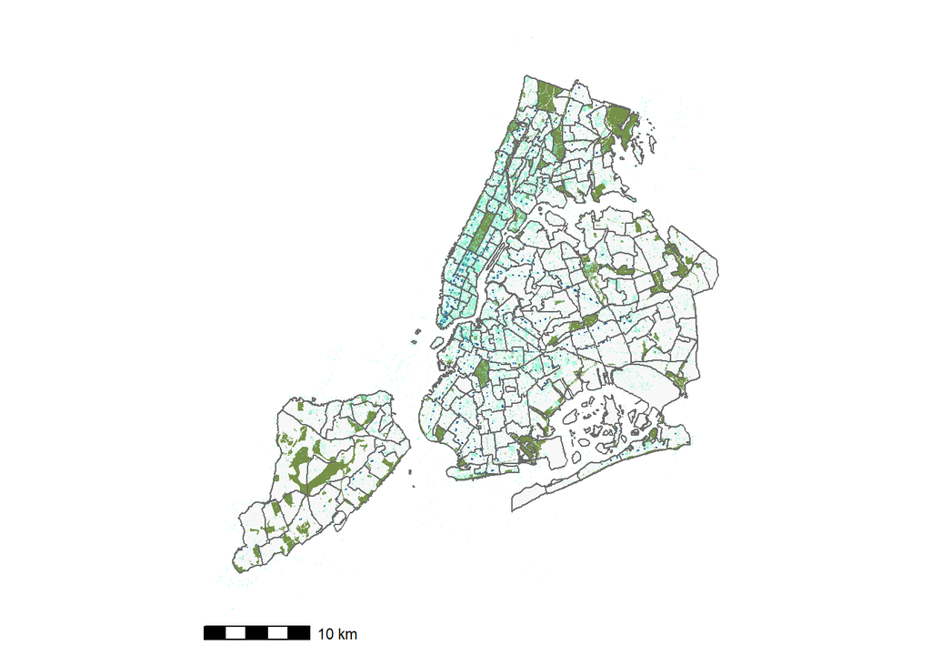

```r
ggplot(parks) +
  geom_sf(fill = "darkolivegreen4", color = NA) +
  geom_sf(data = subway, color = "dodgerblue4", size = 0.1) +
  geom_sf(data = poi, color = "aquamarine", fill = NA, alpha = 0.2, size = 0.001) +
  geom_sf(data = nhoods, fill = "gray", color = "dimgray", alpha = 0.1) +
  theme_map() +
  annotation_scale()
```